# Assignment 5

Janice Luong  
STA 141B  
Feb 24, 2017

In this assignment, you'll scrape text from [The California Aggie](https://theaggie.org/) and then analyze the text.

The Aggie is organized by category into article lists. For example, there's a [Campus News](https://theaggie.org/campus/) list, [Arts & Culture](https://theaggie.org/arts/) list, and [Sports](https://theaggie.org/sports/) list. Notice that each list has multiple pages, with a maximum of 15 articles per page.

The goal of exercises 1.1 - 1.3 is to scrape articles from the Aggie for analysis in exercise 1.4.

**Exercise 1.1.** Write a function that extracts all of the links to articles in an Aggie article list. The function should:

- Have a parameter `url` for the URL of the article list.
- Have a parameter `page` for the number of pages to fetch links from. The default should be `1`.
- Return a list of aricle URLs (each URL should be a string).

Test your function on 2-3 different categories to make sure it works.

Hints:

- Be polite to The Aggie and save time by setting up [requests_cache](https://pypi.python.org/pypi/requests-cache) before you write your function.
- Start by getting your function to work for just 1 page. Once that works, have your function call itself to get additional pages.
- You can use [lxml.html](http://lxml.de/lxmlhtml.html) or [BeautifulSoup](https://www.crummy.com/software/BeautifulSoup/bs4/doc/) to scrape HTML. Choose one and use it throughout the entire assignment.

```python
import requests
import requests_cache
import pandas as pd
import json
import lxml
from bs4 import BeautifulSoup as bs
import numpy as np
import nltk
from nltk import corpus
from nltk.stem.porter import PorterStemmer
from stop_words import get_stop_words
from sklearn.feature_extraction.text import TfidfVectorizer
from sklearn.neighbors import NearestNeighbors
from scipy.sparse import csr_matrix
from matplotlib import pyplot as plt
import seaborn as sns
import sys
import re
from itertools import izip
%matplotlib inline

# Set up a cache for requests.
requests_cache.install_cache("cache")
```

```python
# Extracts all of the links to articles in an Aggie article list
def get_aggie_articles(category, pages = 1, verbose = False):
    # Create an empty list to store the article URLs
    articleURLs = []

    # For each each page that the user requests, get the 15 URLs and store it into the list articleURLs
    for page in range(1, pages + 1):
        url = "https://theaggie.org/" + category + "/page/" + str(page)
        # "Clicks" the page
        opener = requests.get(url)

        if verbose:
            print opener.url

        # Downloads the data
        html_doc = opener.content
        html_parse = bs(html_doc, 'lxml-html') #lxml-html

        # Within the element h2 for class 'entry-title', get the attribute 'a href'
        entry_title = html_parse.findAll('h2', class_ = 'entry-title')
        for tag in entry_title:
            # Get the URL to the article
            tdTags = tag.find_all('a')[0]['href']
            # Add the URL to the list I created earlier to store the URLs
            articleURLs.append(tdTags)

        # Get the attribute 'a next page-numbers'
        next_page = html_parse.findAll('a', class_ = 'next page-numbers')
        # At the last page, the length of next_page will be 0 because the next button will not exist, otherwise it is 1
        if len(next_page) == 0:
            break
    return articleURLs
```

The function above grabs all the links to the 15 articles in the given page number. It then returns all the article URLs as a string. Below is an example of how the function works.

```python
get_aggie_articles("sports", pages = 1)
```

```
['https://theaggie.org/2017/02/24/uc-davis-back-on-track-with-win-over-matadors/',
 'https://theaggie.org/2017/02/24/aggie-womens-basketball-team-says-neigh-to-mustangs/',
 'https://theaggie.org/2017/02/23/the-amazeing-aggies/',
 'https://theaggie.org/2017/02/23/uc-davis-womens-water-polo-dominates-aggie-shootout/',
 'https://theaggie.org/2017/02/23/womens-gymnastics-take-two/',
 'https://theaggie.org/2017/02/21/what-are-your-thoughts-on-uc-davis-athletics/',
 'https://theaggie.org/2017/02/20/a-day-in-the-life-of-an-athletic-trainer/',
 'https://theaggie.org/2017/02/19/a-lifetime-of-tennis/',
 'https://theaggie.org/2017/02/17/uc-davis-womens-basketball-team-holds-off-uc-irvine-62-42/',
 'https://theaggie.org/2017/02/17/nba-awards-at-the-all-star-break/',
 'https://theaggie.org/2017/02/17/womens-lacrosse-soars-over-the-blackbirds/',
 'https://theaggie.org/2017/02/17/uc-davis-womens-lacrosse-falls-in-tough-season-opener/',
 'https://theaggie.org/2017/02/16/uc-davis-softball-falls-in-home-opener/',
 'https://theaggie.org/2017/02/16/ags-compensate-for-recent-loss-to-highlanders-with-decisive-win/',
 'https://theaggie.org/2017/02/13/uc-davis-athletes-excel-academically/']
```

**Exercise 1.2.** Write a function that extracts the title, text, and author of an Aggie article. The function should:

- Have a parameter `url` for the URL of the article.
- For the author, extract the "Written By" line that appears at the end of most articles. You don't have to extract the author's name from this line.
- Return a dictionary with keys "url", "title", "text", and "author". The values for these should be the article url, title, text, and author, respectively.

For example, for [this article](https://theaggie.org/2017/02/14/project-toto-aims-to-address-questions-regarding-city-finances/) your function should return something similar to this:

```
{
    'author': u'Written By: Bianca Antunez \xa0\u2014\xa0city@theaggie.org',
    'text': u'Davis residents create financial model to make city\'s financial state more transparent To increase transparency between the city\'s financial situation and the community, three residents created a model called Project Toto which aims to improve how the city communicates its finances in an easily accessible design. Jeff Miller and Matt Williams, who are members of Davis\' Finance and Budget Commission, joined together with Davis entrepreneur Bob Fung to create the model plan to bring the project to the Finance and Budget Commission in February, according to Kelly Stachowicz, assistant city manager. "City staff appreciate the efforts that have gone into this, and the interest in trying to look at the city\'s potential financial position over the long term," Stachowicz said in an email interview. "We all have a shared goal to plan for a sound fiscal future with few surprises. We believe the Project Toto effort will mesh well with our other efforts as we build the budget for the next fiscal year and beyond." Project Toto complements the city\'s effort to amplify the transparency of city decisions to community members. The aim is to increase the understanding about the city\'s financial situation and make the information more accessible and easier to understand. The project is mostly a tool for public education, but can also make predictions about potential decisions regarding the city\'s financial future. Once completed, the program will allow residents to manipulate variables to see their eventual consequences, such as tax increases or extensions and proposed developments "This really isn\'t a budget, it is a forecast to see the intervention of these decisions," Williams said in an interview with The Davis Enterprise. "What happens if we extend the sales tax? What does it do given the other numbers that are in?" Project Toto enables users, whether it be a curious Davis resident, a concerned community member or a city leader, with the ability to project city finances with differing variables. The online program consists of the 400-page city budget for the 2016-2017 fiscal year, the previous budget, staff reports and consultant analyses. All of the documents are cited and accessible to the public within Project Toto. "It\'s a model that very easily lends itself to visual representation," Mayor Robb Davis said. "You can see the impacts of decisions the council makes on the fiscal health of the city." Complementary to this program, there is also a more advanced version of the model with more in-depth analyses of the city\'s finances. However, for an easy-to-understand, simplistic overview, Project Toto should be enough to help residents comprehend Davis finances. There is still more to do on the project, but its creators are hard at work trying to finalize it before the 2017-2018 fiscal year budget. "It\'s something I have been very much supportive of," Davis said. "Transparency is not just something that I have been supportive of but something we have stated as a city council objective [ ] this fits very well with our attempt to inform the public of our challenges with our fiscal situation." ',
    'title': 'Project Toto aims to address questions regarding city finances',
    'url': 'https://theaggie.org/2017/02/14/project-toto-aims-to-address-questions-regarding-city-finances/'
}
```

Hints:

- The author line is always the last line of the last paragraph.
- Python 2 displays some Unicode characters as `\uXXXX`. For instance, `\u201c` is a left-facing quotation mark. You can convert most of these to ASCII characters with the method call (on a string)

  ```
  .translate({ 0x2018:0x27, 0x2019:0x27, 0x201C:0x22, 0x201D:0x22, 0x2026:0x20 })
  ```

  If you're curious about these characters, you can look them up on [this page](http://unicode.org/cldr/utility/character.jsp), or read more about [what Unicode is](http://unicode.org/standard/WhatIsUnicode.html).

```python
# import warnings
# warnings.filterwarnings('ignore')

def get_URL_details(one_URL):
    opener = requests.get(one_URL)

    # Downloads the data
    html_doc = opener.content
    html_parse = bs(html_doc, 'lxml-html')

    url = one_URL
    # Get only the text of the element 'h1' for entry-title
    title = html_parse.find_all('h1', class_ = 'entry-title')[0].text
    # Get the entire body content of the article, but only where it is in the tags <p>, which contains the article
    body = html_parse.find_all('div', {'itemprop' : 'articleBody'})[0].find_all('p')
    # Create an empty string, which will be used to store the author and text later
    author = str()
    text = str()

    # Start a counter, which I will use to help me find the author
    #i = 0

    # For each paragraoh, store it into text.
    for content in body:
        text += content.text + '\n'
        #i += 1
    text = text.split('\n')

    i = 0

    while len(author) == 0:
        i += 1
        author = text[-i]

    # Select the article body to variable text, without the author
    text = '\n'.join(text[:-i])

    # Python 2 displays some Unicode characters as \uXXXX,
    # convert most of the to ASCII characters with the method call (on a string)
    text = text.translate({ 0x2018:0x27, 0x2019:0x27, 0x201C:0x22, 0x201D:0x22, 0x2026:0x20 })

    # order: url, title, text, and author
    url_info = {"url" : url
                , "title": title
                , "text" : text.replace('\n', '')
                , "author" : author
               }
    return url_info
```

I do this by starting at the bottom of the text variable and moving my way up until I find the first line. I need to do this because sometimes the line after the second to last sentence is just a new line and contains no content. Sometimes the last line is not the author, but also a new line. So starting from the bottom until I grabbed the first line with content ensured that I will grab the author because the author is always the last line of content in any article.

I then removed the author from the variable text.

```python
# An example of what the function get_URL_details() outputs
get_URL_details("https://theaggie.org/2017/02/14/project-toto-aims-to-address-questions-regarding-city-finances/")
```

```
{'author': u'Written By: Bianca Antunez \xa0\u2014\xa0city@theaggie.org',
 'text': u'Davis residents create financial model to make city\'s financial state more transparentTo increase transparency between the city\'s financial situation and the community, three residents created a model called Project Toto which aims to improve how the city communicates its finances in an…
 'title': u'Project Toto aims to address questions regarding city finances',
 'url': 'https://theaggie.org/2017/02/14/project-toto-aims-to-address-questions-regarding-city-finances/'}
```

**Exercise 1.3.** Use your functions from exercises 1.1 and 1.2 to get a data frame of 60 [Campus News](https://theaggie.org/campus/) articles and a data frame of 60 [City News](https://theaggie.org/city/) articles. Add a column to each that indicates the category, then combine them into one big data frame.

The "text" column of this data frame will be your corpus for natural language processing in exercise 1.4.

```python
type_of_articles = get_aggie_articles("city", pages = 4) + get_aggie_articles("campus", pages = 4)

# No need to specify the columns because pandas.DataFrame.append()
# Append rows of other to the end of this frame, returning a new object and
# columns not in this frame are added as new columns
all_article_data = pd.DataFrame()

# For a progress tracker
# count = 0.0
# final = len(type_of_articles)

# The indexes for the dictionary are used for the column names
for article in type_of_articles:
    # For a progress tracker
    # count += 1
    article_info = get_URL_details(article)
    all_article_data = all_article_data.append(article_info, ignore_index = True)
    # For a progress tracker
    # print str((count / final)*100) + "%"

from IPython.core.display import display, HTML

# Force it to display every single row
# display(HTML(all_article_data.to_html()))
all_article_data.head()
```

|  | author | text | title | url |
| --- | --- | --- | --- | --- |
| 0 | Written by: Kaelyn Tuermer-Lee — city@theaggie... | Local Whole Foods closes Feb. 12After five yea... | Davis’ Whole Foods Market shuts down | https://theaggie.org/2017/02/23/davis-whole-fo... |
| 1 | Written By: Anya Rehon — city@theaggie.org | Demonstrations take place at hundreds of Plann... | Protest against Planned Parenthood in Woodland... | https://theaggie.org/2017/02/23/protest-agains... |
| 2 | Written By: Bianca Antunez — city@theaggie.org | California Redevelopment Agencies require Davi... | Davis’s Historic City Hall building to be put ... | https://theaggie.org/2017/02/23/daviss-histori... |
| 3 | Written by: Caitlyn Sampley — city@theaggie.org | Davis residents show solidarity in wake of tra... | Davis stands with Muslim residents | https://theaggie.org/2017/02/21/davis-stands-w... |
| 4 | Written By: Anya Rehon — city@theaggie.org | CalRecycle donates $197,851The City of Davis w... | City of Davis awarded funds for new recycling ... | https://theaggie.org/2017/02/20/city-of-davis-... |

I storedthe data, a dictionary, into a dataframe. When using the function .append(), I do not need tp specify the columns because the function appends rows of other to the end of this frame, returning a new object and columns not in this frame are added as new columns. So .append() used the dictionary keys' as the column names.

**Exercise 1.4.** Use the Aggie corpus to answer the following questions. Use plots to support your analysis.

- What topics does the Aggie cover the most? Do city articles typically cover different topics than campus articles?
- What are the titles of the top 3 pairs of most similar articles? Examine each pair of articles. What words do they have in common?
- Do you think this corpus is representative of the Aggie? Why or why not? What kinds of inference can this corpus support? Explain your reasoning.

Hints:

- The [nltk book](http://www.nltk.org/book/) and [scikit-learn documentation](http://scikit-learn.org/stable/modules/feature_extraction.html#text-feature-extraction) may be helpful here.
- You can determine whether city articles are "near" campus articles from the similarity matrix or with k-nearest neighbors.
- If you want, you can use the [wordcloud](http://amueller.github.io/word_cloud/) package to plot a word cloud. To install the package, run

  ```
  conda install -c https://conda.anaconda.org/amueller wordcloud
  ```

  in a terminal. Word clouds look nice and are easy to read, but are less precise than bar plots.

I worked with Chad Pickering and Ricky Safran.

```python
stemmer = PorterStemmer().stem
tokenize = nltk.word_tokenize

def stem(tokens, stemmer = PorterStemmer().stem):
    return [stemmer(w.lower()) for w in tokens]

def lemmatize(text):
    """
    Extract simple lemmas based on tokenization and stemming
    Input: string
    Output: list of strings (lemmata)
    """
    return stem(tokenize(text))

# Seperate each individual word
# Code taken from instructor
lemmata = [lemmatize(x) for x in all_article_data["text"]]
_lemmata = [item for sublist in lemmata for item in sublist]

stop_words = get_stop_words('english')
stop_words += ["said","really","wa","thi","ha","can"
               ,"going","also","come","don't","will"
               ,"uc","davi","davis","year","campus"
               ,"city","police","logs","yolo","day"]
# Remove stop words from the list (words that do not add any meaning eg "the")
important_words = [t for t in _lemmata if t not in stop_words]

# Make a list of unique words
uniqWords = sorted(set(important_words))
```

I seperated each individial word and then filtered out "stop words", using the stopwords package in Python. I also added additional stop words that were not part of the package, but that I felt did not add any content telling us what the articles are about. For example, we know the words Davis, or UC will show up often because this is an online newspaper about Davis.

```python
# This is equivalent to the set [^a-zA-Z0-9_]
some_punct = re.compile('\W')
# Create an empty dataframe to store all the word along with its count
all_words_text = pd.DataFrame()

# For the progress counter
count = 0
final = len(uniqWords)
hund_final = final/100
print str(final) + " total words to iterate through"
print "will update every " + str(hund_final) + " words"

# Loops through every word and grabs only the ones that does not contain a punctuation or number
for word in uniqWords:
    count += 1
    # Make a progress counter
    if count % hund_final == 0:
        # Replace the previous output so its not a long list of percentages
        sys.stdout.write('\r' + str(round(count*100.0 / final, 1)) + "% finished...")
    # Skips words with no letters or numbers
    if some_punct.search(word) != None:
        continue
    dict_words = {"word" : word, "count": important_words.count(word)}
    all_words_text = all_words_text.append(dict_words, ignore_index = True)
    #print important_words.count(word), word
sys.stdout.write('\r' + "100% finished!")
```

```
5677 total words to iterate through
will update every 56 words
100% finished!...
```

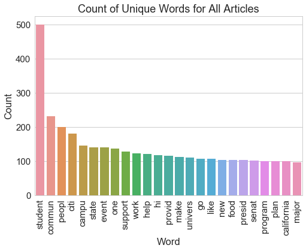

```python
# Set the size of plot or else its too small to read
plt.rcParams['figure.figsize'] = (10, 10)
sns.set(font_scale = 1.5)

sns.set_style("whitegrid")
fruit_bar = sns.barplot(x = "word", y = "count"
                        , data = all_words_text.sort_values(by = all_words_text.columns[0], ascending = False).head(n = 25))
for item in fruit_bar.get_xticklabels():
    item.set_rotation(90)
sns.plt.title('Count of Unique Words for All Articles')
fruit_bar.set(ylabel = 'Count', xlabel = 'Word')
sns.plt.show()
```

I used a bar plot because although Word clouds look nice and are easy to read, they are less precise than bar plots.

The topics that The Aggie covers the most are related to the community, support, helping others, going places/events, senates, education, major and presidents (could be school president or USA's president). Overall both city and campus article discuss a lot about the campus (UC Davis) and about local events for the community.

```python
# Make each word a
lemmata = [lemmatize(x) for x in all_article_data["text"][0:60]]
_lemmata = [item for sublist in lemmata for item in sublist]

# Remove stop words from the list (words that do not add any meaning eg "the")
important_words = [t for t in _lemmata if t not in stop_words]

# Make a list of unique words
uniqWords = sorted(set(important_words))
```

```python
all_words_text = pd.DataFrame()

count = 0
final = len(uniqWords)
hund_final = final/100

print str(final) + " total words to iterate through"
print "will update every " + str(hund_final) + " words"

for word in uniqWords:
    count += 1
    if count % hund_final == 0:
        sys.stdout.write('\r' + str(round(count*100.0 / final, 1)) + "% finished...")
    # Skips words with no letters or numbers
    if some_punct.search(word) != None:
        continue
    dict_words = {"word" : word, "count": important_words.count(word)}
    all_words_text = all_words_text.append(dict_words, ignore_index = True)
    #print important_words.count(word), word
sys.stdout.write('\r' + "100% finished!")
```

```
3727 total words to iterate through
will update every 37 words
100% finished!...
```

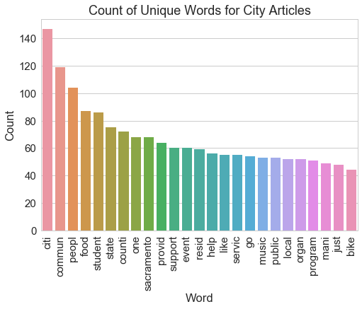

```python
plt.rcParams['figure.figsize'] = (10, 10)
sns.set(font_scale = 1.5)

sns.set_style("whitegrid")
fruit_bar = sns.barplot(x = "word", y = "count"
                        , data = all_words_text.sort_values(by = all_words_text.columns[0], ascending = False).head(n = 25))
for item in fruit_bar.get_xticklabels():
    item.set_rotation(90)
sns.plt.title('Count of Unique Words for City Articles')
fruit_bar.set(ylabel = 'Count', xlabel = 'Word')
sns.plt.show()
```

The plot above shows generally what type of topics city articles covers. In general, city articles covers topics about students, Sacramento (a near by city), food, the state (most likely California), the public, and providing things for the general people. It also talks about things that people may "like".

```python
# Make each word a
lemmata = [lemmatize(x) for x in all_article_data["text"][60:]]
_lemmata = [item for sublist in lemmata for item in sublist]

# Remove stop words from the list (words that do not add any meaning eg "the")
important_words = [t for t in _lemmata if t not in stop_words]

# Make a list of unique words
uniqWords = sorted(set(important_words))
```

```python
all_words_text = pd.DataFrame()

count = 0
final = len(uniqWords)
hund_final = final/100

print str(final) + " total words to iterate through"
print "will update every " + str(hund_final) + " words"

for word in uniqWords:
    count += 1
    if count % hund_final == 0:
        sys.stdout.write('\r' + str(round(count*100.0 / final, 1)) + "% finished...")
    # Skips words with no letters or numbers
    if some_punct.search(word) != None:
        continue
    dict_words = {"word" : word, "count": important_words.count(word)}
    all_words_text = all_words_text.append(dict_words, ignore_index = True)
    #print important_words.count(word), word
sys.stdout.write('\r' + "100% finished!")
```

```
3862 total words to iterate through
will update every 38 words
100% finished!...
```

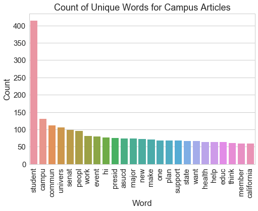

```python
plt.rcParams['figure.figsize'] = (10, 10)
sns.set(font_scale = 1.5)

sns.set_style("whitegrid")
fruit_bar = sns.barplot(x = "word", y = "count"
                        , data = all_words_text.sort_values(by = all_words_text.columns[0], ascending = False).head(n = 25))
for item in fruit_bar.get_xticklabels():
    item.set_rotation(90)
sns.plt.title('Count of Unique Words for Campus Articles')
fruit_bar.set(ylabel = 'Count', xlabel = 'Word')
sns.plt.show()
```

The city article mostly covers topics relating to the general public and events happening in near by cities (such as Sacramento). While the campus articles covers topics mostly about the students and what services or support are available for students.

```python
# This code was taken from the professor
vectorizer = TfidfVectorizer(tokenizer = lemmatize, stop_words = "english", smooth_idf = True, norm = None)
tfs = vectorizer.fit_transform(all_article_data["text"])
sim = tfs.dot(tfs.T)
sim_matrix = csr_matrix(sim)
get_mat = sim_matrix.tocoo()

# Sort the list based on the first column and then the third column
# where the columns are: base article, comparison articles, and similiarty score
# Which will allow me to use list comprehension to find the top values
def sort_coo(mat):
    tuples = izip(mat.row, mat.col, mat.data)
    return sorted(tuples, key = lambda x: (x[0], x[2]), reverse = True)

ordered_sim = sort_coo(get_mat)
# Start from the first row and skip every 120 articles
# because the top similarity is every 120 articles since
# it was already ordered
same_art = ordered_sim[0::120]

# Create an empty list, which is where the pairs of matching articles will go
most_similar_art = []
# If the articles are differnt (not the same article comparing to itself), then add them to the list of most similar articles
for x in range(len(same_art)):
    if (same_art[x][0] != same_art[x][1]) == True:
        most_similar_art.append(same_art[x])

sorted(most_similar_art, key=lambda x: x[2], reverse = True)[0:3]
```

```
[(71, 76, 13091.474056059189),
 (87, 76, 12608.552833576534),
 (117, 76, 11083.256740568806)]
```

Above is the matrix I used to find 3 pairs of articles that are similar. It compares the top similairty scores for each of the 120 articles. It them sorts the list by the base article then by similarity score. After it is ordered, it starts from the first row and skip every 120 articles because the top similarity is every 120 articles since it was already ordered, so skip every 120 articles. Finally, I added each article that is not comparing itself to the list of most_similar_art because if it is comparing itself, then it would have the highest similarity score. Comparing an article to itself does not tell us anything.

The top 3 pairs of articles that are most similar to each other are:

1. "UC Davis Global Affais holds discussion on President Donald Trump’s executive orders on immigration" vs. "2017 ASUCD Winter Elections - Meet the Candidates"
2. "Senator Bill Dodd visits UC Davis" vs. "2017 ASUCD Winter Elections - Meet the Candidates"
3. "UCs receive record-breaking number of applicants" vs. "2017 ASUCD Winter Elections - Meet the Candidates"

Notice that all the articles above are from the "campus" article section.

Next I will take a look at each pair by making bar plot of the combined frequencies for the words they have in common to help possibly explain why "2017 ASUCD Winter Elections - Meet the Candidates" appears in each pair.

```python
all_article_data.iloc[[71]]
```

|  | author | text | title | url |
| --- | --- | --- | --- | --- |
| 71 | Written by: Kenton Goldsby — campus@theaggie.org | Speakers, including Interim Chancellor Ralph J... | UC Davis Global Affairs holds discussion on Pr... | https://theaggie.org/2017/02/19/uc-davis-globa... |

```python
all_article_data.iloc[[76]]
```

|  | author | text | title | url |
| --- | --- | --- | --- | --- |
| 76 | Written by: Alyssa Vandenberg and Emilie DeFaz... | Executive: Josh Dalavai and Adilla JamaludinIn... | 2017 ASUCD Winter Elections — Meet the Candidates | https://theaggie.org/2017/02/16/2017-asucd-win... |

```python
all_article_data.iloc[[87]]
```

|  | author | text | title | url |
| --- | --- | --- | --- | --- |
| 87 | Written by: Ivan Valenzuela — campus@theaggie.org | Davis College Democrats host Dodd for question... | Senator Bill Dodd visits UC Davis | https://theaggie.org/2017/02/06/senator-bill-d... |

```python
all_article_data.iloc[[117]]
```

|  | author | text | title | url |
| --- | --- | --- | --- | --- |
| 117 | Written by: Jeanna Totah — campus@theaggie.org | Increase in applications brings more diverse p... | UCs receive record-breaking number of applicants | https://theaggie.org/2017/01/15/ucs-receive-re... |

```python
lemmata = [lemmatize(x) for x in all_article_data.iloc[[71,76],:]["text"]]
_lemmata = [item for sublist in lemmata for item in sublist]

# Remove stop words from the list (words that do not add any meaning eg "the")
important_words = [t for t in _lemmata if t not in stop_words]

# Make a list of unique words
uniqWords = sorted(set(important_words))
```

```python
all_words_text = pd.DataFrame()

count = 0
final = len(uniqWords)
hund_final = final/100

print str(final) + " total words to iterate through"
print "will update every " + str(hund_final) + " words"

for word in uniqWords:
    count += 1
    if count % hund_final == 0:
        sys.stdout.write('\r' + str(round(count*100.0 / final, 1)) + "% finished...")
    # Skips words with no letters or numbers
    if some_punct.search(word) != None:
        continue
    dict_words = {"word" : word, "count": important_words.count(word)}
    all_words_text = all_words_text.append(dict_words, ignore_index = True)
    #print important_words.count(word), word
sys.stdout.write('\r' + "100% finished!")
```

```
697 total words to iterate through
will update every 6 words
100% finished!...
```

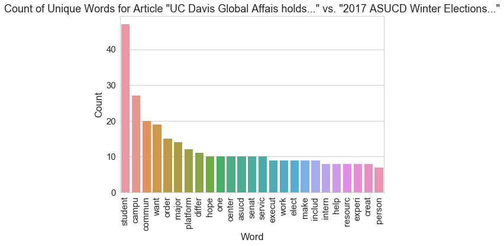

```python
plt.rcParams['figure.figsize'] = (10, 10)
sns.set(font_scale = 1.5)

sns.set_style("whitegrid")
fruit_bar = sns.barplot(x = "word", y = "count"
                        , data = all_words_text.sort_values(by = all_words_text.columns[0], ascending = False).head(n = 25))
for item in fruit_bar.get_xticklabels():
    item.set_rotation(90)
sns.plt.title('Count of Unique Words for Article "UC Davis Global Affais holds..." vs. "2017 ASUCD Winter Elections..."')
fruit_bar.set(ylabel = 'Count', xlabel = 'Word')
sns.plt.show()
```

For articles: "UC Davis Global Affais holds discussion on President Donald Trump’s executive orders on immigration" vs. "2017 ASUCD Winter Elections - Meet the Candidates":

The most common words shared among them in the text column are student, campus, want, order, major and asucd. All these words are related to an election in a sense that generally, during an election, the canidate talks about what changes or orders they want and how this would affect the UC Davis campus (the students).

```python
lemmata = [lemmatize(x) for x in all_article_data.iloc[[87,76],:]["text"]]
_lemmata = [item for sublist in lemmata for item in sublist]

# Remove stop words from the list (words that do not add any meaning eg "the")
important_words = [t for t in _lemmata if t not in stop_words]

# Make a list of unique words
uniqWords = sorted(set(important_words))
```

```python
all_words_text = pd.DataFrame()

count = 0
final = len(uniqWords)
hund_final = final/100

print str(final) + " total words to iterate through"
print "will update every " + str(hund_final) + " words"

for word in uniqWords:
    count += 1
    if count % hund_final == 0:
        sys.stdout.write('\r' + str(round(count*100.0 / final, 1)) + "% finished...")
    # Skips words with no letters or numbers
    if some_punct.search(word) != None:
        continue
    dict_words = {"word" : word, "count": important_words.count(word)}
    all_words_text = all_words_text.append(dict_words, ignore_index = True)
    #print important_words.count(word), word
sys.stdout.write('\r' + "100% finished!")
```

```
647 total words to iterate through
will update every 6 words
100% finished!...
```

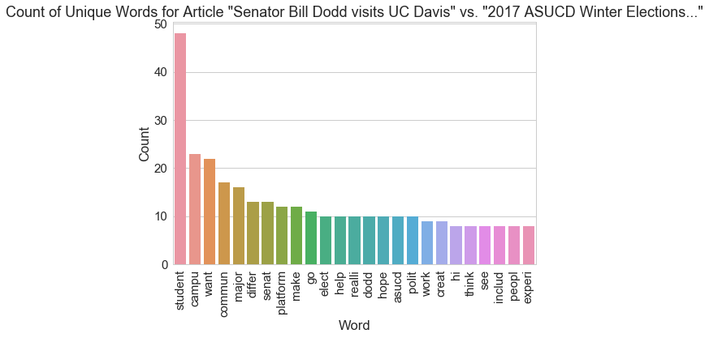

```python
plt.rcParams['figure.figsize'] = (10, 10)
sns.set(font_scale = 1.5)

sns.set_style("whitegrid")
fruit_bar = sns.barplot(x = "word", y = "count"
                        , data = all_words_text.sort_values(by = all_words_text.columns[0], ascending = False).head(n = 25))
for item in fruit_bar.get_xticklabels():
    item.set_rotation(90)
sns.plt.title('Count of Unique Words for Article "Senator Bill Dodd visits UC Davis" vs. "2017 ASUCD Winter Elections..."')
fruit_bar.set(ylabel = 'Count', xlabel = 'Word')
sns.plt.show()
```

For the articles "Senator Bill Dodd visits UC Davis" vs. "2017 ASUCD Winter Elections - Meet the Candidates":

The most common words shared among them in the text column are student, want, major, differ, senate, plateform and make. All these words are related to an election also and it seems the mention the word senate quite often and how these senates or candiates will affect the UC Davis campus.

```python
lemmata = [lemmatize(x) for x in all_article_data.iloc[[117,76],:]["text"]]
_lemmata = [item for sublist in lemmata for item in sublist]

# Remove stop words from the list (words that do not add any meaning eg "the")
important_words = [t for t in _lemmata if t not in stop_words]

# Make a list of unique words
uniqWords = sorted(set(important_words))
```

```python
all_words_text = pd.DataFrame()

count = 0
final = len(uniqWords)
hund_final = final/100

print str(final) + " total words to iterate through"
print "will update every " + str(hund_final) + " words"

for word in uniqWords:
    count += 1
    if count % hund_final == 0:
        sys.stdout.write('\r' + str(round(count*100.0 / final, 1)) + "% finished...")
    # Skips words with no letters or numbers
    if some_punct.search(word) != None:
        continue
    dict_words = {"word" : word, "count": important_words.count(word)}
    all_words_text = all_words_text.append(dict_words, ignore_index = True)
    #print important_words.count(word), word
sys.stdout.write('\r' + "100% finished!")
```

```
670 total words to iterate through
will update every 6 words
100% finished!...
```

[figure not shown]

```python
plt.rcParams['figure.figsize'] = (10, 10)
sns.set(font_scale = 1.5)

sns.set_style("whitegrid")
fruit_bar = sns.barplot(x = "word", y = "count"
                        , data = all_words_text.sort_values(by = all_words_text.columns[0], ascending = False).head(n = 25))
for item in fruit_bar.get_xticklabels():
    item.set_rotation(90)
sns.plt.title('Count of Unique Words for Article "UCs receive record-breaking..." vs. "2017 ASUCD Winter Elections..."')
fruit_bar.set(ylabel = 'Count', xlabel = 'Word')
sns.plt.show()
```

For the articles "UCs receive record-breaking number of applicants" vs. "2017 ASUCD Winter Elections - Meet the Candidates":

The most common words shared among them in the text column are student, campus, want community, increase and senate. All these words are related to the campus community and possiblilty how the increase in students or increase in tuition may affect the students and the candidates "about me" part mentions how they may help alleviate the cost of tutition for students who do not recieve financial aid.

The reason why the different articles were considered "similar" the "2017 ASUCD Winter..." article is because after removing all the stop words, the shorter articles will have a lot of words repeated inside a longer article, which will likely have much more unique words than a short article even after removing the stop words.

This causes short articles in having a high sparse matrix score with a long article than compared to another short article because since the sprase matrix scores are not weighted' therefore, similaries implires how many times the word occurs.

All 4 of the articles came from the campus articles and none from the city articls. This may be because all the city articles were likely short and after removing all the stop words, it did not have many similar unique words in common with each other. But the article from campus called "2017 ASUCD Winter..." is the longest out of all of them so it was being matched up with many other shorter articles from campus articles.